# Analysis of Variance Report 1

Melinda Higgins

October 1, 2016

[figure not shown]

R Exercises Logo

## R Exercises - One-Way Analysis of Variance

The following exercise comes from [R Exercises at http://r-exercises.com/](http://r-exercises.com/), which is a site created by Research for Decisions, a Dutch research/consulting firm. They provide many exercises for learning R and practicing R coding skills. They also provide a large list of courses available for learning R - both free and paid - with detailed summaries of each option at http://r-exercises.com/r-courses/.

## Assumptions

When the data shows non-normality, unequal variance or presence of outliers, the data can be “transformed” *(such as square-root or log transformations to help skewness)* or a non-parametric test like Kruskal-Wallis can be used. It is good to note Kruskal-Wallis does not require normality of data but still requires equal variance in your groups. *[Note: There are transformation alternatives for handling unequal variances which will not be covered in this exercise.]*

## Load Data

For this exercise, the data come from patients having stomach, colon, ovary, brochus, or breast cancer. The objective of the study was to identify if the number of days a patient survived was influenced by the organ affected. Our dependent variable is Survival measured in days. Our independent variable is Organ.

The data is available at http://lib.stat.cmu.edu/DASL/Datafiles/CancerSurvival.html. The dataset we’re going to upload is the `cancer-survival.csv` file.

Since this dataset is a CSV (comma-delimited) formatted file, we can use the r function `read.csv()` to read in the dataset. This function returns a `data.frame` which we “assign” to the object `cancer.survival`.

## Look at data

Let’s “look” at the data. We can use the `head()` function to look at the top 5-6 rows of the dataset.

```
##   Survival   Organ
## 1      124 Stomach
## 2       42 Stomach
## 3       25 Stomach
## 4       45 Stomach
## 5      412 Stomach
## 6       51 Stomach
```

We can clean up the looks for this output by using the `kable()` function from the `knitr` package to put the output into a table.

| Survival | Organ |
| --- | --- |
| 124 | Stomach |
| 42 | Stomach |
| 25 | Stomach |
| 45 | Stomach |
| 412 | Stomach |
| 51 | Stomach |

## Select data and get stats

To select one of the columns in the dataset we can use the `$` selector to “select” by the variable name. You can see the column names using the `names()` function.

```
## [1] "Survival" "Organ"
```

For example, we can find the mean survival time using the `mean()` function and selecting the 1st column which is `Survival` in the data frame `cancer.survival` using the followng code `mean(cancer.survival$Survival)`.

```
## [1] 558.625
```

We can also get summary statistics for the `Survival` column using the `summary()` function.

```
##    Min. 1st Qu.  Median    Mean 3rd Qu.    Max.
##    20.0   102.5   265.5   558.6   721.0  3808.0
```

Since the 1st column `Survival` is a continuous variable, the `summary()` function gives us the min, max, median, 1st and 3rd quartiles. Let’s see what we get for the 2nd column, which is the list of Organs - it is a non-numeric text categorical variable.

```
##   Breast Bronchus    Colon    Ovary  Stomach
##       11       17       17        6       13
```

We basically got the list of the Organs and the count (or frequency) of how many subjects survival times (i.e. number of data points) we have for each Organ. We can use the `summary()` command for the dataset as a whole and get the summary stats for both variables at the same time. If we use the `knitr::kable()` function around this summary, we get a nice summary stats table. Let’s also add a caption.

Table of Summary Statistics for 2 Variables in Dataset

|  | Survival | Organ |
| --- | --- | --- |
|  | Min. : 20.0 | Breast :11 |
|  | 1st Qu.: 102.5 | Bronchus:17 |
|  | Median : 265.5 | Colon :17 |
|  | Mean : 558.6 | Ovary : 6 |
|  | 3rd Qu.: 721.0 | Stomach :13 |
|  | Max. :3808.0 | NA |

## Let’s try some inline code

Suppose I want to write a sentence providing the mean and standard deviation of the survival times seen across this dataset. We can use the functions `mean()` and `sd()` and use them “inline” - see example below.

The average survival time was 558.625 days with a standard deviation of 776.4786713 days.

Another way to do this is to assign the mean and standard deviation to objects and then just call those objects. This simplifies the inline code commands and can help in cleaning up your formatting. We can also use the `round()` function with the `digits=` option to set the number of digits to 1 or 2. Let’s create 2 objects one for the mean `mnsurv` and one for the standard deviation `sdsurv` and then use these to re-write the sentence. We’ll also use the `round()` function and set the number of digits (after the decimal place) to 2.

The average survival time was 558.62 days with a standard deviation of 776.48 days.

## Let’s make a histogram of the survival times.

Using the `hist()` function, let’s make a histogram of the survival times overall and add a title.

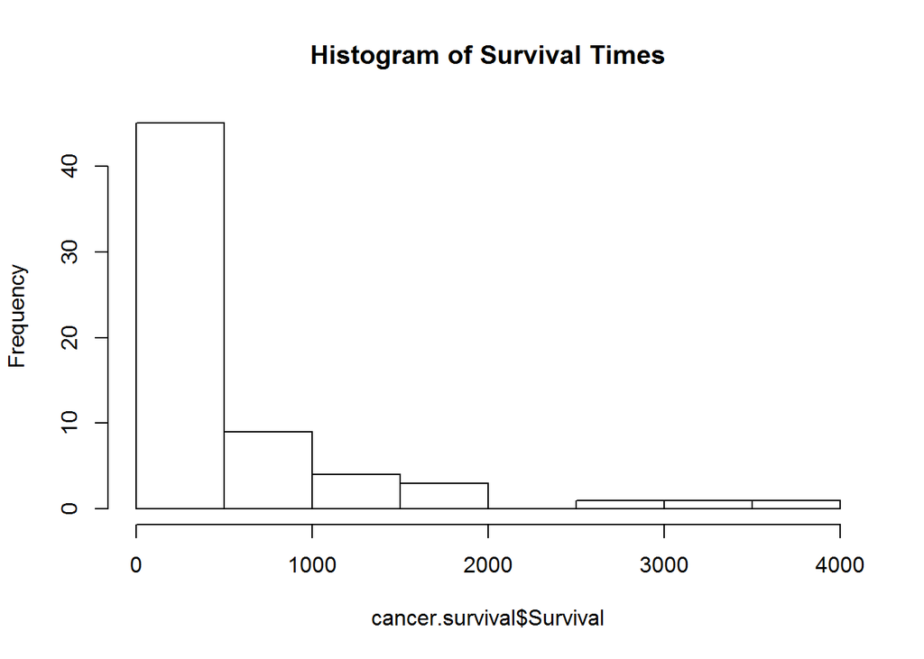

**What do you notice about the distribution?**

## Make side-by-side boxplots of survival times by organ

For this plot we are going to use the `ggplot2` package and functions. So we have to install the package and load it.

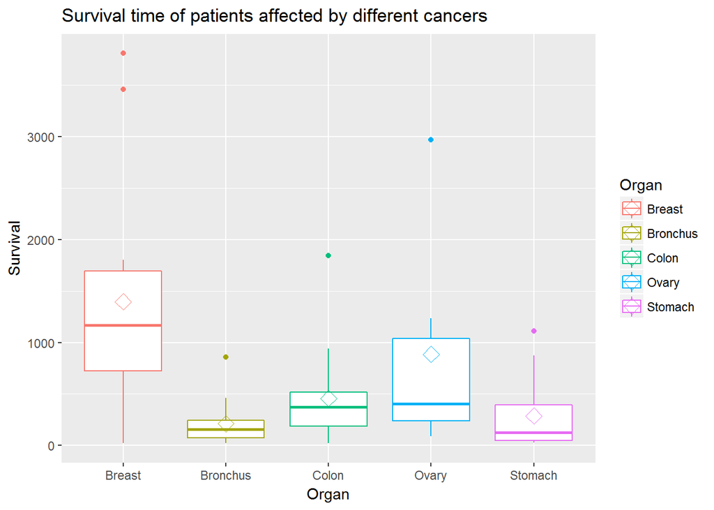

## Summary Statistics for Survival by Organ

We can use the `psych` package and the `describeBy()` function to get summary statisics by group.

```
## group: Breast
##    vars  n    mean      sd median trimmed    mad min  max range skew
## X1    1 11 1395.91 1238.97   1166 1280.33 662.72  24 3808  3784 0.81
##    kurtosis     se
## X1     -0.7 373.56
## --------------------------------------------------------
## group: Bronchus
##    vars  n   mean     sd median trimmed    mad min max range skew kurtosis
## X1    1 17 211.59 209.86    155   181.2 133.43  20 859   839 1.75     2.66
##      se
## X1 50.9
## --------------------------------------------------------
## group: Colon
##    vars  n   mean     sd median trimmed    mad min  max range skew
## X1    1 17 457.41 427.17    372   394.2 244.63  20 1843  1823 1.96
##    kurtosis    se
## X1     3.76 103.6
## --------------------------------------------------------
## group: Ovary
##    vars n   mean      sd median trimmed    mad min  max range skew
## X1    1 6 884.33 1098.58    406  884.33 386.96  89 2970  2881 1.01
##    kurtosis     se
## X1    -0.75 448.49
## --------------------------------------------------------
## group: Stomach
##    vars  n mean     sd median trimmed    mad min  max range skew kurtosis
## X1    1 13  286 346.31    124  234.64 121.57  25 1112  1087 1.27     0.25
##       se
## X1 96.05
```

## Perform a One-way Analysis of Variance

We’ll begin by checking assumptions.

### Check normality assumptions

For this we will use the `shapiro.test()` function along with `tapply()` and `with()`.

```
## $Breast
##
##  Shapiro-Wilk normality test
##
## data:  X[[i]]
## W = 0.86857, p-value = 0.07431
##
##
## $Bronchus
##
##  Shapiro-Wilk normality test
##
## data:  X[[i]]
## W = 0.76596, p-value = 0.0007186
##
##
## $Colon
##
##  Shapiro-Wilk normality test
##
## data:  X[[i]]
## W = 0.76056, p-value = 0.0006134
##
##
## $Ovary
##
##  Shapiro-Wilk normality test
##
## data:  X[[i]]
## W = 0.76688, p-value = 0.029
##
##
## $Stomach
##
##  Shapiro-Wilk normality test
##
## data:  X[[i]]
## W = 0.75473, p-value = 0.002075
```

### Check for equality of variance

To check the assumption of equal variances between the groups (Organ in this case), we’ll use `leveneTest()` from the `car` package.

```
## Levene's Test for Homogeneity of Variance (center = median)
##       Df F value   Pr(>F)
## group  4  4.4524 0.003271 **
##       59
## ---
## Signif. codes:  0 '***' 0.001 '**' 0.01 '*' 0.05 '.' 0.1 ' ' 1
```

### Apply a log transformation to survival time and check for normality and equality of variance.

```
## $Breast
##
##  Shapiro-Wilk normality test
##
## data:  X[[i]]
## W = 0.802, p-value = 0.009995
##
##
## $Bronchus
##
##  Shapiro-Wilk normality test
##
## data:  X[[i]]
## W = 0.98047, p-value = 0.9613
##
##
## $Colon
##
##  Shapiro-Wilk normality test
##
## data:  X[[i]]
## W = 0.92636, p-value = 0.1891
##
##
## $Ovary
##
##  Shapiro-Wilk normality test
##
## data:  X[[i]]
## W = 0.983, p-value = 0.9655
##
##
## $Stomach
##
##  Shapiro-Wilk normality test
##
## data:  X[[i]]
## W = 0.92837, p-value = 0.3245
```

### Check levene’s test again

```
## Levene's Test for Homogeneity of Variance (center = median)
##       Df F value Pr(>F)
## group  4  0.6685 0.6164
##       59
```

### Perform one way anova

```
##             Df Sum Sq Mean Sq F value  Pr(>F)
## Organ        4  24.49   6.122   4.286 0.00412 **
## Residuals   59  84.27   1.428
## ---
## Signif. codes:  0 '***' 0.001 '**' 0.01 '*' 0.05 '.' 0.1 ' ' 1
```

### Clean up ANOVA model fit summary

Since `saov1` is a list of 1 object (which you can confirm by running `class(saov1)`), we select this 1st object which is a data frame which will work with knitr. Run `class(saov1[[1]])` to confirm that this is a data frame.

ANOVA of Log-Survival by Organ

|  | Df | Sum Sq | Mean Sq | F value | Pr(>F) |
| --- | --- | --- | --- | --- | --- |
| Organ | 4 | 24.48656 | 6.121639 | 4.285967 | 0.004122 |
| Residuals | 59 | 84.26959 | 1.428298 | NA | NA |

## Alternative Non-parametric One-way ANOVA

### Use a kruskal-wallis test

```
##
##  Kruskal-Wallis rank sum test
##
## data:  log.survival by Organ
## Kruskal-Wallis chi-squared = 14.954, df = 4, p-value = 0.004798
```